# Zero-inflated Data

BH Analytics, LLC

# Zero Inflated Data

In this session, we will discuss modeling techniques used for zero inflated data. We will cover the following:

- Identifying zero inflated data
- Sample dataset: sale amounts
- Issues with normal regression on zero-inflated data
- Using distributions that explicitly account for zero inflation
- Modeling ‘structural zero’s’: hurdle model frameworks

# Sample Data: Sales Data

- Typical zero-inflated data is identified by a large point mass at zero (pretty self explanatory)!
- Let’s import some simulated sales data which exhibits this behaviour.

```r
library(readr)
library(dplyr)
library(Hmisc)
# Import sales data using dplyr / tidyverse
sales_df <-
  read_csv('data/customer_sales1.csv')
# describe dataset
describe(sales_df)
```

```
## sales_df
##
##  16  Variables      8000  Observations
## --------------------------------------------------------------------------------------------------------------------------------------------------------
## customer_id
##        n  missing distinct     Info     Mean      Gmd      .05      .10      .25      .50      .75      .90      .95
##     8000        0     8000        1   104987     3329   100498   100986   102496   104989   107472   108984   109481
##
## lowest : 100000 100001 100002 100003 100004, highest: 109995 109996 109997 109998 109999
## --------------------------------------------------------------------------------------------------------------------------------------------------------
## sale
##        n  missing distinct
##     8000        0        2
##
## Value         No   Yes
## Frequency   3235  4765
## Proportion 0.404 0.596
## --------------------------------------------------------------------------------------------------------------------------------------------------------
## sale_amount
##        n  missing distinct     Info     Mean      Gmd      .05      .10      .25      .50      .75      .90      .95
##     8000        0     4737    0.934      249    320.3      0.0      0.0      0.0    118.8    418.9    697.9    875.1
##
## lowest :    0.000   10.000   10.000   10.000   10.000, highest: 1834.651 1881.856 1927.765 2075.270 2111.991
## --------------------------------------------------------------------------------------------------------------------------------------------------------
## region
##        n  missing distinct     Info     Mean      Gmd      .05      .10      .25      .50      .75      .90      .95
##     8000        0       50        1    25.42    16.64        3        5       13       26       38       45       48
##
## lowest :  1  2  3  4  5, highest: 46 47 48 49 50
## --------------------------------------------------------------------------------------------------------------------------------------------------------
## age
##        n  missing distinct     Info     Mean      Gmd      .05      .10      .25      .50      .75      .90      .95
##     8000        0       77    0.999    59.13    12.67       41       45       51       59       67       74       78
##
## lowest :  21  22  23  25  26, highest:  94  95  97  98 100
## --------------------------------------------------------------------------------------------------------------------------------------------------------
## gender
##        n  missing distinct
##     8000        0        2
##
```

[output cut: 65 more lines]

```
## --------------------------------------------------------------------------------------------------------------------------------------------------------
## current_customer
##        n  missing distinct
##     8000        0        2
##
## Value         No   Yes
## Frequency   5647  2353
## Proportion 0.706 0.294
## --------------------------------------------------------------------------------------------------------------------------------------------------------
## income
##        n  missing distinct     Info     Mean      Gmd      .05      .10      .25      .50      .75      .90      .95
##     8000        0       71    0.999    64.79    11.21       49       52       58       65       71       78       81
##
## lowest :  26  31  32  33  34, highest:  96  98 101 102 103
## --------------------------------------------------------------------------------------------------------------------------------------------------------
```

# Exploring the outcome of Sale Amount

- Let’s look at the outcome of sale amount. We will explore different approaches to modeling this outcome.
- First, we can visualize the distribution. Do you think you could call this distribution ‘zero inflated’?
- This is a common trait of data, especially data with an underlying binary process. The only way someone spends money is if they decide to buy something…therefore sale amount is really a combination of two different distributions. The first is a binary process of ‘did you buy something’, then the second is a positive continuous distribution that asks ‘How much did you spend’?

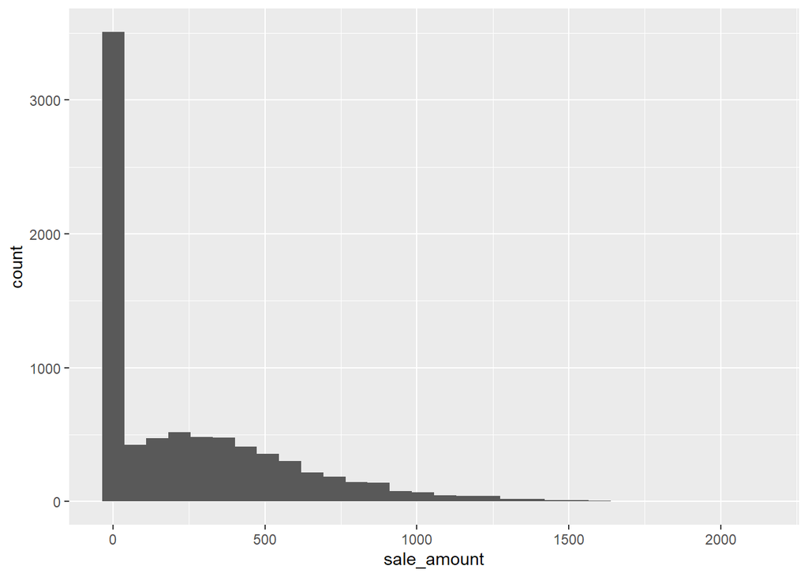

```r
library(ggplot2)
ggplot(sales_df,aes(x=sale_amount)) +
  geom_histogram()
```

# Fitting a Normal Regression

- If we are interested in modeling this data, we could start by simply fitting a normal linear regression like so:

```r
# Calculate mean:
mean(sales_df$sale_amount)
```

```
## [1] 248.9774
```

```r
# Fit Linear model to estimate mean
mod1_lm <- lm(sale_amount~1,
              data=sales_df)
summary(mod1_lm)
```

```
##
## Call:
## lm(formula = sale_amount ~ 1, data = sales_df)
##
## Residuals:
##    Min     1Q Median     3Q    Max
## -249.0 -249.0 -130.2  169.9 1863.0
##
## Coefficients:
##             Estimate Std. Error t value Pr(>|t|)
## (Intercept)  248.977      3.514   70.85   <2e-16 ***
## ---
## Signif. codes:  0 '***' 0.001 '**' 0.01 '*' 0.05 '.' 0.1 ' ' 1
##
## Residual standard error: 314.3 on 7999 degrees of freedom
```

- The estimate of the mean looks unbiased here…so is there a problem with the inflated zeros?
- Technically a normal linear regression is robust to the underlying distribution of the data when estimating the mean! - So the data does not have to be normally distributed, as long as we have a large enough number of observations (recall the central limit theorum).
- However, if we examine the residuals of the model, we find some odd patterns that may bother you…they are certainly not normally distributed around zero!

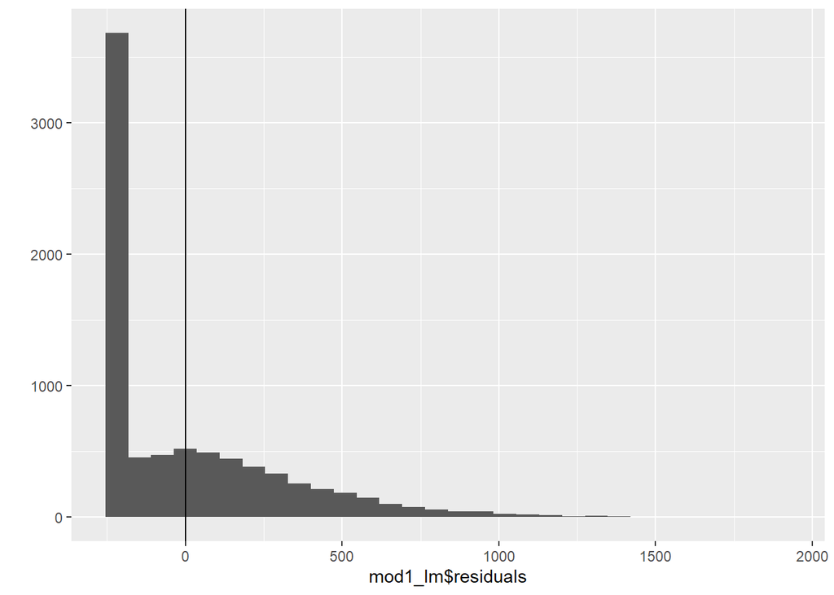

```r
qplot(mod1_lm$residuals) +
  geom_vline(xintercept = 0)
```

# Fitting a normal regression with predictors

- What if we are trying to understand the impact of age on sale amount? We may try to put in a linear trend for age to explore this.

```r
# Fit Linear model to age - sale_amount relationship
mod2_lm <- lm(sale_amount~age,
              data=sales_df)
summary(mod2_lm)
```

```
##
## Call:
## lm(formula = sale_amount ~ age, data = sales_df)
##
## Residuals:
##    Min     1Q Median     3Q    Max
## -479.4 -227.0 -117.7  171.2 1704.8
##
## Coefficients:
##             Estimate Std. Error t value Pr(>|t|)
## (Intercept) -84.3906    18.4902  -4.564 5.09e-06 ***
## age           5.6383     0.3073  18.350  < 2e-16 ***
## ---
## Signif. codes:  0 '***' 0.001 '**' 0.01 '*' 0.05 '.' 0.1 ' ' 1
##
## Residual standard error: 307.9 on 7998 degrees of freedom
## Multiple R-squared:  0.0404, Adjusted R-squared:  0.04028
## F-statistic: 336.7 on 1 and 7998 DF,  p-value: < 2.2e-16
```

- Is this model a good fit? We may explore the residuals across age to better understand:

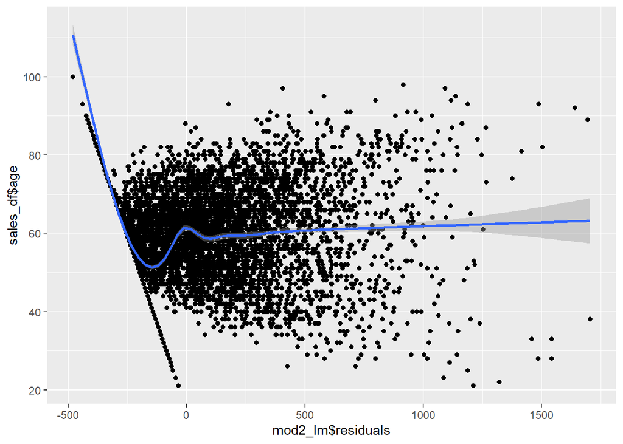

```r
# Look for pattern in age residuals....
qplot(mod2_lm$residuals,sales_df$age) +
  geom_smooth()
```

- That is hard to interpret! Perhaps we should try a model that overtly recognizes the zero inflated nature of this distribution?
- Let’s start by trying a simple Poisson GLM model.

# Fitting a Poison Model to this data:

- I am going to round the sale amount to the nearest dollar for the purpose of showing the Poisson models, which typically are used for count outcomes. An example might be ‘modeling the number of insurance claims’
- We can then fit a standard Poisson model on this data, and show the zero inflated Poisson distributions as well.

```r
# Round sale amount
sales_df$sale_amount_round <- round(sales_df$sale_amount)
```

```r
# Fit Poisson Model
mod1_poisson <-
  glm(sale_amount_round~1,
      data=sales_df,
      family=poisson(link='log'))
summary(mod1_poisson)
```

```
##
## Call:
## glm(formula = sale_amount_round ~ 1, family = poisson(link = "log"),
##     data = sales_df)
##
## Deviance Residuals:
##     Min       1Q   Median       3Q      Max
## -22.315  -22.315   -9.179    9.805   72.835
##
## Coefficients:
##              Estimate Std. Error z value Pr(>|z|)
## (Intercept) 5.5173676  0.0007086    7787   <2e-16 ***
## ---
## Signif. codes:  0 '***' 0.001 '**' 0.01 '*' 0.05 '.' 0.1 ' ' 1
##
## (Dispersion parameter for poisson family taken to be 1)
##
##     Null deviance: 3129726  on 7999  degrees of freedom
## Residual deviance: 3129726  on 7999  degrees of freedom
## AIC: 3165465
##
## Number of Fisher Scoring iterations: 6
```

```r
# check for predicted mean by exponentiating intercept
exp(mod1_poisson$coefficients)
```

```
## (Intercept)
##    248.9788
```

- That isn’t far off from our answer using the normal approach!
- But what happens when we include age, then try to make some predictions?

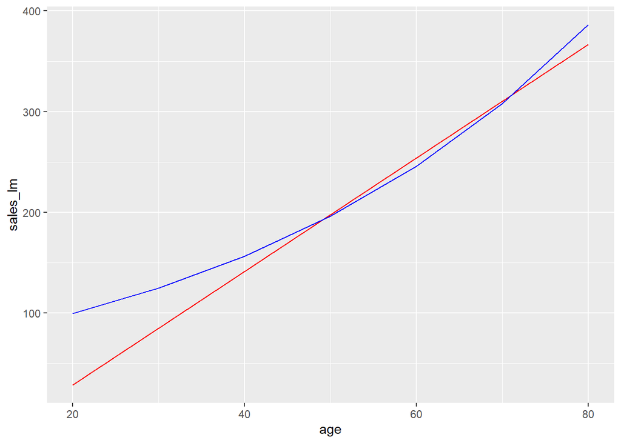

```r
# Fit Poisson Model with age
mod2_poisson <-
  glm(sale_amount_round~age,
      data=sales_df,
      family=poisson(link='log'))
df_pred <-
  data.frame(age=c(20,30,40,50,60,70,80))
# make predictions
df_pred$sales_lm <-
  predict(mod2_lm,
          newdata = df_pred)
df_pred$sales_poisson <-
  predict(mod2_poisson,
          newdata = df_pred,
          type = 'response')
# show difference
ggplot(df_pred,aes(x=age)) +
  geom_line(color='red',
            aes(y=sales_lm)) +
  geom_line(color='blue',
            aes(y=sales_poisson))
```

- These give very different results!
- This is why getting the model ‘right’ matters. There are two ways in which we can a model ‘wrong’:
- The first way is by parameterizing the model incorrectly. Perhaps Age should be a non-linear term in this model? Or the link function should be multiplicative (like the Poisson) instead of additive (the normal regression is additive)?
- The second way we can get it wrong is by incorrectly estimating the uncertainty in our model (the variance).
- It is true to claim that the central limit theorum says we do not need to care about the underlying ‘shape’ of the distribution of the data when implementing a normal regression. However, we still have to correctly parameterize the model, or the results will be wrong.

# The ‘Tweedie’ Distribution

- We can actually use a distribution which incorporates the excess zeros directly!
- One such distribution is the tweedie distribution, which is defined as Poisson sum of Gamma Variables. More details can be found at the wiki page [here](https://en.wikipedia.org/wiki/Tweedie_distribution)
- For now, I will just simulate the tweedie to show you what it can look like:

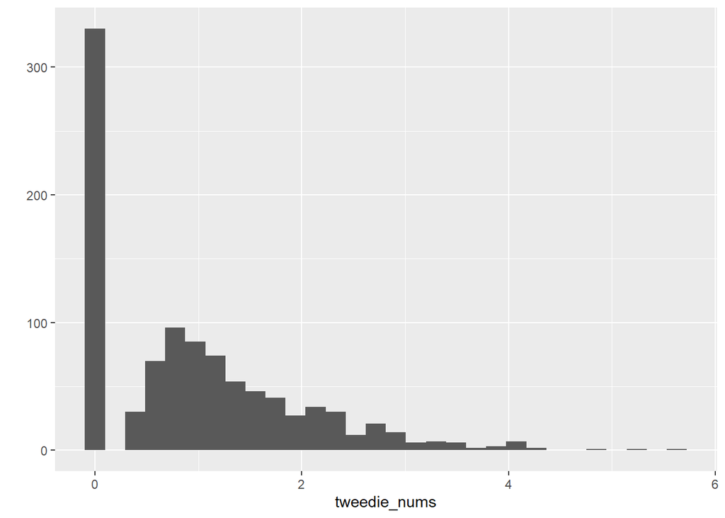

```r
# Simulate the tweedie distribution!
library(mgcv)
tweedie_nums <- rTweedie(mu = rep(1,1000),p = 1.1,phi = 1)
qplot(tweedie_nums)
```

# Fitting a Tweedie Model

- It turns out you can fit a general linear model with a tweedie family!
- You need to identify the optimal ‘p’ parameter first, then you can call the glm and specify the ‘p’ parameter.
- This may take some profiling time on your computer, but the code below gives you a sense of how to fit the model.

```r
library(statmod)
library(tweedie)
## find best 'p' parameter
# this takes awhile to run...
prof <- tweedie.profile(sale_amount_round~1,
                        data=sales_df,
                        p.vec = seq(1.1,1.9,.1))
prof$p.max
```

```r
library(statmod)
library(tweedie)
## fit glm with the chosen p parameter from above.
mod1_tweed <-
  glm(sale_amount_round~1,
      data=sales_df,
      family = tweedie(var.power = 1.1,
                       link.power = 0))
## check results
summary(mod1_tweed)
```

```
##
## Call:
## glm(formula = sale_amount_round ~ 1, family = tweedie(var.power = 1.1,
##     link.power = 0), data = sales_df)
##
## Deviance Residuals:
##     Min       1Q   Median       3Q      Max
## -17.851  -17.851   -7.047    7.375   53.093
##
## Coefficients:
##             Estimate Std. Error t value Pr(>|t|)
## (Intercept)  5.51737    0.01411   390.9   <2e-16 ***
## ---
## Signif. codes:  0 '***' 0.001 '**' 0.01 '*' 0.05 '.' 0.1 ' ' 1
##
## (Dispersion parameter for Tweedie family taken to be 228.5314)
##
##     Null deviance: 1878197  on 7999  degrees of freedom
## Residual deviance: 1878197  on 7999  degrees of freedom
## AIC: NA
##
## Number of Fisher Scoring iterations: 6
```

```r
## exponeniate the parameter (log link)
exp(mod1_tweed$coefficients) # pretty close!
```

```
## (Intercept)
##    248.9788
```

```r
mean(sales_df$sale_amount_round)
```

```
## [1] 248.9787
```

```r
## add age to the model
mod2_tweed <-
  glm(sale_amount_round~age,
      data=sales_df,
      family = tweedie(var.power = 1.1,
                       link.power = 0))
summary(mod2_tweed)
```

```
##
## Call:
## glm(formula = sale_amount_round ~ age, family = tweedie(var.power = 1.1,
##     link.power = 0), data = sales_df)
##
## Deviance Residuals:
##     Min       1Q   Median       3Q      Max
## -26.245  -16.755   -6.883    7.439   56.263
##
## Coefficients:
##             Estimate Std. Error t value Pr(>|t|)
## (Intercept) 4.205859   0.077973   53.94   <2e-16 ***
## age         0.021680   0.001246   17.40   <2e-16 ***
## ---
## Signif. codes:  0 '***' 0.001 '**' 0.01 '*' 0.05 '.' 0.1 ' ' 1
##
## (Dispersion parameter for Tweedie family taken to be 223.6608)
##
##     Null deviance: 1878197  on 7999  degrees of freedom
## Residual deviance: 1807547  on 7998  degrees of freedom
## AIC: NA
##
## Number of Fisher Scoring iterations: 6
```

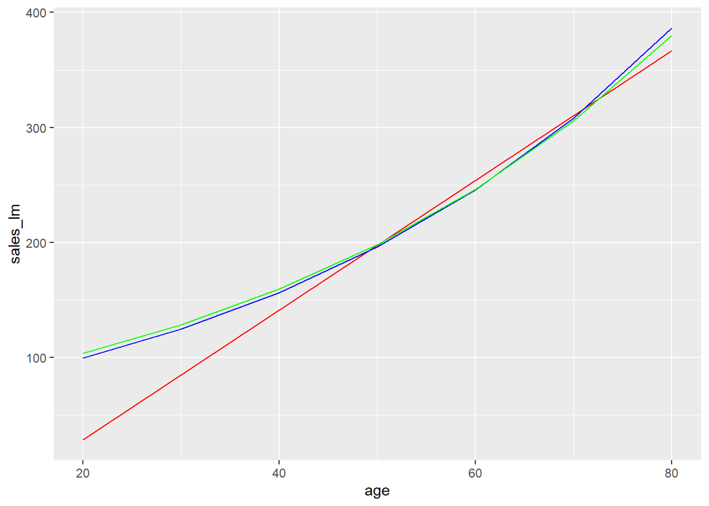

```r
## add predictions and check
df_pred$sales_tweedie <-
  predict(mod2_tweed,
          newdata = df_pred,
          type = 'response')
# show difference
ggplot(df_pred,aes(x=age)) +
  geom_line(color='red',
            aes(y=sales_lm)) +
  geom_line(color='blue',
            aes(y=sales_poisson)) +
  geom_line(color='green',
            aes(y=sales_tweedie))
```

- The tweedie regression is very close to the Poisson regression in the prediction, but there are minor differences at young and old ages.
- In the tweedie model, we are simply fitting a general linear model with a new distributional family.
- We cannot identify all the parameters we need, so you have to take the extra profiling step to identify `p` as shown above.
- What else can we do to model these excess zeros?

# Two-Stage Models and Mixtures

# Consider a Zero-Inflated Poisson

- Let’s fit a zero inflated Poisson first.
- Remember, this is a mixture distribution!
- There may be an issue with ‘overdispersion’ in this Poisson model, which we will address in a moment.
- Notice the output we receive include information about two different regression models!
- The first model is the count model, which potentially includes values of zero and higher.
- The second model is the zero-inflation model, which estimates if the outcome is zero, or part of the count distribution (which may also be zero…)

```r
library(pscl)
# fit basic model
mod1_zip <-
  zeroinfl(sale_amount_round~1,
           data=sales_df,
           dist='poisson')
summary(mod1_zip)
```

```
##
## Call:
## zeroinfl(formula = sale_amount_round ~ 1, data = sales_df, dist = "poisson")
##
## Pearson residuals:
##     Min      1Q  Median      3Q     Max
## -1.2101 -1.2101 -0.6317  0.8263  9.0546
##
## Count model coefficients (poisson with log link):
##              Estimate Std. Error z value Pr(>|z|)
## (Intercept) 6.0355116  0.0007086    8518   <2e-16 ***
##
## Zero-inflation model coefficients (binomial with logit link):
##             Estimate Std. Error z value Pr(>|z|)
## (Intercept) -0.38727    0.02278     -17   <2e-16 ***
## ---
## Signif. codes:  0 '***' 0.001 '**' 0.01 '*' 0.05 '.' 0.1 ' ' 1
##
## Number of iterations in BFGS optimization: 1
## Log-likelihood: -5.561e+05 on 2 Df
```

```r
# predict the response. Only one possible value (intercept only model)
# so I only retrieve the first prediction
predict(mod1_zip,type = 'response')[1]
```

```
##        1
## 248.9788
```

```r
# we get the same mean again!
```

```r
# How about looking at age?
mod2_zip <-
  zeroinfl(sale_amount_round~age,
           data=sales_df,
           dist='poisson')
summary(mod2_zip)
```

```
##
## Call:
## zeroinfl(formula = sale_amount_round ~ age, data = sales_df, dist = "poisson")
##
## Pearson residuals:
##     Min      1Q  Median      3Q     Max
## -1.8315 -1.1576 -0.6248  0.8497 11.7149
##
## Count model coefficients (poisson with log link):
##              Estimate Std. Error z value Pr(>|z|)
## (Intercept) 5.140e+00  3.991e-03  1287.8   <2e-16 ***
## age         1.467e-02  6.336e-05   231.6   <2e-16 ***
##
## Zero-inflation model coefficients (binomial with logit link):
##              Estimate Std. Error z value Pr(>|z|)
## (Intercept)  0.799970   0.123585   6.473  9.6e-11 ***
## age         -0.020162   0.002071  -9.736  < 2e-16 ***
## ---
## Signif. codes:  0 '***' 0.001 '**' 0.01 '*' 0.05 '.' 0.1 ' ' 1
##
## Number of iterations in BFGS optimization: 1
## Log-likelihood: -5.293e+05 on 4 Df
```

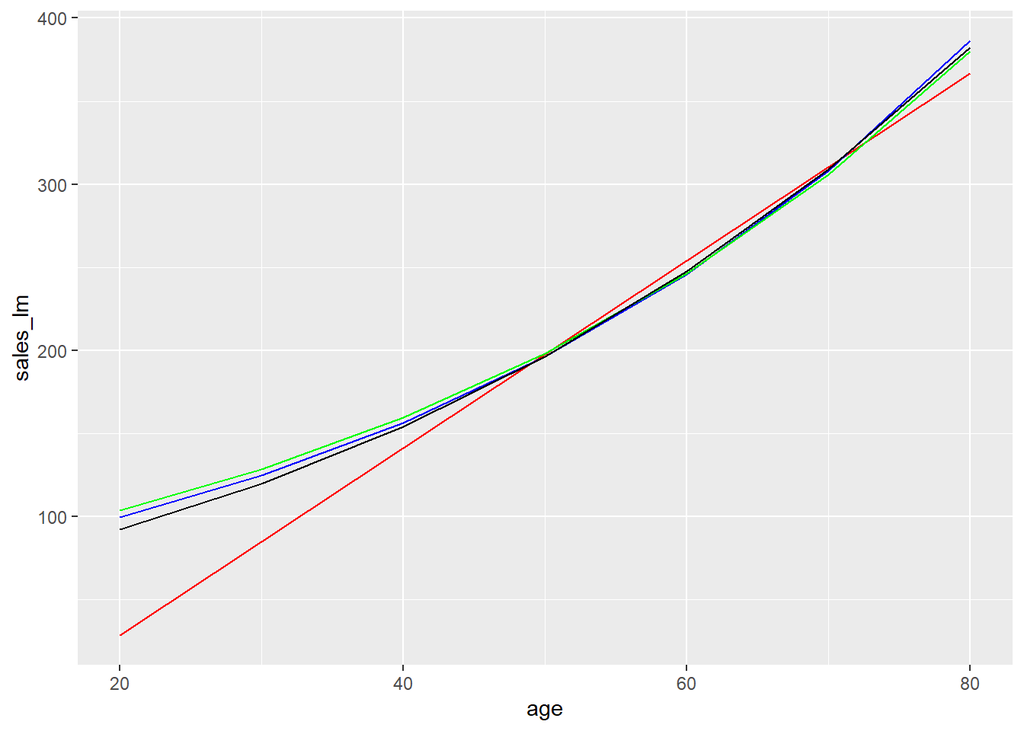

```r
# check age predictions
df_pred$sales_zip <-
  predict(mod2_zip,
          newdata = df_pred,
          type = 'response')
# show difference
ggplot(df_pred,aes(x=age)) +
  geom_line(color='red',
            aes(y=sales_lm)) +
  geom_line(color='blue',
            aes(y=sales_poisson)) +
  geom_line(color='green',
            aes(y=sales_tweedie)) +
  geom_line(color='black',
            aes(y=sales_zip))
```

```r
# Check table
df_pred
```

```
##   age  sales_lm sales_poisson sales_tweedie sales_zip
## 1  20  28.37493      99.62601      103.4877   92.0292
## 2  30  84.75768     124.87628      128.5412  119.6338
## 3  40 141.14044     156.52624      159.6599  153.9634
## 4  50 197.52319     196.19791      198.3122  196.1439
## 5  60 253.90594     245.92439      246.3220  247.3851
## 6  70 310.28869     308.25407      305.9545  308.9904
## 7  80 366.67144     386.38125      380.0235  382.3808
```

- The zero inflated model predicts a bit lower values for younger folks!
- So what about overdispersion here? Perhaps the assumption of mean equals variance in the Poisson portion is unreasonable.
- We can try a zero inflated negative binomial to get more accurate confidence intervals (assuming there is overdispersion!)

# Fit a Zero Inflated Negative Binomial!

- We can replace the Poisson portion of the model with a negative binomial.
- It works exactly the same way, we just specify a new family:

```r
# fit basic model
mod1_zinb <-
  zeroinfl(sale_amount_round~1,
           data=sales_df,
           dist='negbin')
summary(mod1_zinb)
```

```
##
## Call:
## zeroinfl(formula = sale_amount_round ~ 1, data = sales_df, dist = "negbin")
##
## Pearson residuals:
##     Min      1Q  Median      3Q     Max
## -0.7433 -0.7433 -0.3880  0.5075  5.5616
##
## Count model coefficients (negbin with log link):
##             Estimate Std. Error z value Pr(>|z|)
## (Intercept)  6.03531    0.01190  507.38   <2e-16 ***
## Log(theta)   0.39788    0.01899   20.95   <2e-16 ***
##
## Zero-inflation model coefficients (binomial with logit link):
##             Estimate Std. Error z value Pr(>|z|)
## (Intercept) -0.38780    0.02279  -17.02   <2e-16 ***
## ---
## Signif. codes:  0 '***' 0.001 '**' 0.01 '*' 0.05 '.' 0.1 ' ' 1
##
## Theta = 1.4887
## Number of iterations in BFGS optimization: 3
## Log-likelihood: -3.872e+04 on 3 Df
```

```r
# predict the response. Only one possible value (intercept only model)
# so I only retrieve the first prediction
predict(mod1_zinb,
        type = 'response')[1]
```

```
##        1
## 248.9811
```

```r
# we get the same mean again!
```

```r
# How about looking at age?
mod2_zinb <-
  zeroinfl(sale_amount_round~age,
           data=sales_df,
           dist='negbin')
summary(mod2_zinb)
```

```
##
## Call:
## zeroinfl(formula = sale_amount_round ~ age, data = sales_df, dist = "negbin")
##
## Pearson residuals:
##     Min      1Q  Median      3Q     Max
## -0.9332 -0.7254 -0.3867  0.5182  6.7817
##
## Count model coefficients (negbin with log link):
##              Estimate Std. Error z value Pr(>|z|)
## (Intercept) 5.4136985  0.0537518  100.72   <2e-16 ***
## age         0.0101811  0.0008718   11.68   <2e-16 ***
## Log(theta)  0.4219101  0.0190153   22.19   <2e-16 ***
##
## Zero-inflation model coefficients (binomial with logit link):
##              Estimate Std. Error z value Pr(>|z|)
## (Intercept)  0.799970   0.123621   6.471 9.73e-11 ***
## age         -0.020169   0.002072  -9.736  < 2e-16 ***
## ---
## Signif. codes:  0 '***' 0.001 '**' 0.01 '*' 0.05 '.' 0.1 ' ' 1
##
## Theta = 1.5249
## Number of iterations in BFGS optimization: 3
## Log-likelihood: -3.861e+04 on 5 Df
```

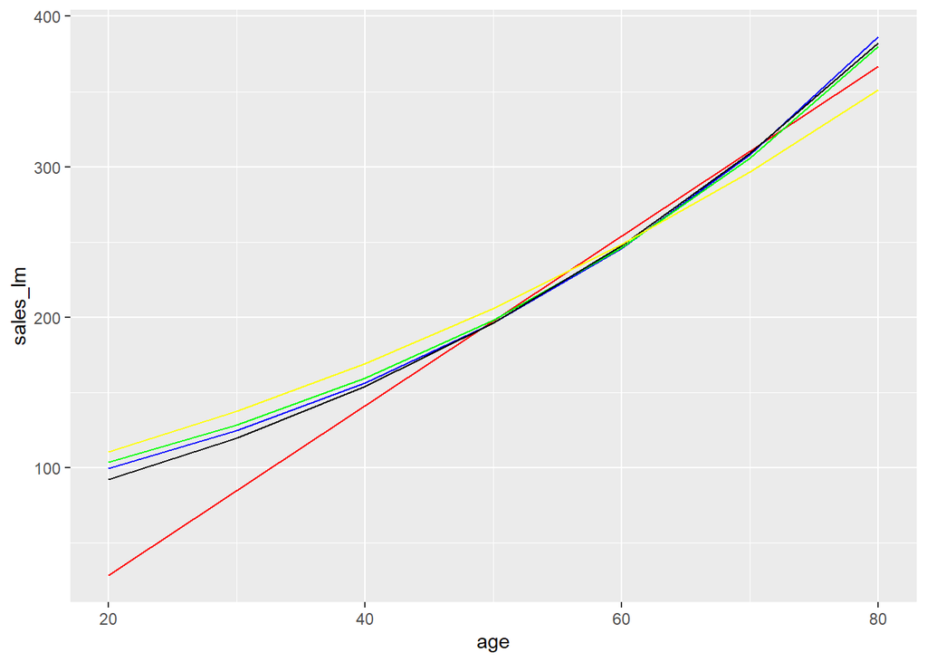

```r
# check age predictions
df_pred$sales_zinb <-
  predict(mod2_zinb,
          newdata = df_pred,
          type = 'response')
# show difference
ggplot(df_pred,aes(x=age)) +
  geom_line(color='red',
            aes(y=sales_lm)) +
  geom_line(color='blue',
            aes(y=sales_poisson)) +
  geom_line(color='green',
            aes(y=sales_tweedie)) +
  geom_line(color='black',
            aes(y=sales_zip)) +
  geom_line(color='yellow',
            aes(y=sales_zinb))
```

```r
# Check table
df_pred
```

```
##   age  sales_lm sales_poisson sales_tweedie sales_zip sales_zinb
## 1  20  28.37493      99.62601      103.4877   92.0292   110.6476
## 2  30  84.75768     124.87628      128.5412  119.6338   137.5243
## 3  40 141.14044     156.52624      159.6599  153.9634   169.2190
## 4  50 197.52319     196.19791      198.3122  196.1439   206.1148
## 5  60 253.90594     245.92439      246.3220  247.3851   248.5463
## 6  70 310.28869     308.25407      305.9545  308.9904   296.8081
## 7  80 366.67144     386.38125      380.0235  382.3808   351.1730
```

# Consider a Hurdle Model- Poisson

- Finally, we can consider a hurdle model as well.
- Recall this is the true two-stage model - in the first stage we estimate if the value is zero or positive. In the second stage, we estimate the positive value.
- The key difference is the zero’s…the only way to have a zero is from the first stage model. This is unlike the mixture models (zero inflated models) we just discussed.
- In the context of our sales model, this makes a lot of conceptual sense. Either you didn’t buy something, or you did and it cost some positive amount of money.
- We use the `hurdle()` function for these models. We will start with a hurdle model using a logistic regression for stage 1, and a Poisson distribution for stage 2.

```r
# fit intercept only model
mod1_hurd_poisson <-
  hurdle(sale_amount_round~1,
         data=sales_df,
         dist='poisson',
         zero.dist = 'binomial')
summary(mod1_hurd_poisson)
```

```
##
## Call:
## hurdle(formula = sale_amount_round ~ 1, data = sales_df, dist = "poisson", zero.dist = "binomial")
##
## Pearson residuals:
##     Min      1Q  Median      3Q     Max
## -1.2101 -1.2101 -0.6317  0.8263  9.0546
##
## Count model coefficients (truncated poisson with log link):
##              Estimate Std. Error z value Pr(>|z|)
## (Intercept) 6.0355116  0.0007086    8518   <2e-16 ***
## Zero hurdle model coefficients (binomial with logit link):
##             Estimate Std. Error z value Pr(>|z|)
## (Intercept)  0.38727    0.02278      17   <2e-16 ***
## ---
## Signif. codes:  0 '***' 0.001 '**' 0.01 '*' 0.05 '.' 0.1 ' ' 1
##
## Number of iterations in BFGS optimization: 7
## Log-likelihood: -5.561e+05 on 2 Df
```

```r
# predict the response. Only one possible value (intercept only model)
# so I only retrieve the first prediction
predict(mod1_hurd_poisson,
        type = 'response')[1]
```

```
##        1
## 248.9788
```

```r
# we get the same mean again!
# How about looking at age?
mod2_hurd_poisson <-
  hurdle(sale_amount_round~age,
         data=sales_df,
         dist='poisson',
         zero.dist = 'binomial')
summary(mod2_hurd_poisson)
```

```
##
## Call:
## hurdle(formula = sale_amount_round ~ age, data = sales_df, dist = "poisson", zero.dist = "binomial")
##
## Pearson residuals:
##     Min      1Q  Median      3Q     Max
## -1.8315 -1.1576 -0.6248  0.8497 11.7151
##
## Count model coefficients (truncated poisson with log link):
##              Estimate Std. Error z value Pr(>|z|)
## (Intercept) 5.140e+00  3.991e-03  1287.8   <2e-16 ***
## age         1.467e-02  6.336e-05   231.6   <2e-16 ***
## Zero hurdle model coefficients (binomial with logit link):
##              Estimate Std. Error z value Pr(>|z|)
## (Intercept) -0.799970   0.123585  -6.473  9.6e-11 ***
## age          0.020162   0.002071   9.736  < 2e-16 ***
## ---
## Signif. codes:  0 '***' 0.001 '**' 0.01 '*' 0.05 '.' 0.1 ' ' 1
##
## Number of iterations in BFGS optimization: 7
## Log-likelihood: -5.293e+05 on 4 Df
```

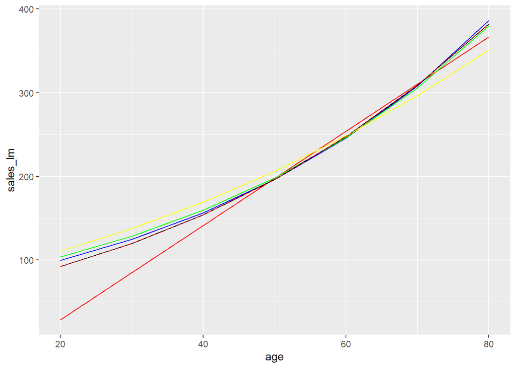

```r
# check age predictions
df_pred$sales_hurd_poisson <-
  predict(mod2_hurd_poisson,
          newdata = df_pred,
          type = 'response')
# show difference
ggplot(df_pred,aes(x=age)) +
  geom_line(color='red',
            aes(y=sales_lm)) +
  geom_line(color='blue',
            aes(y=sales_poisson)) +
  geom_line(color='green',
            aes(y=sales_tweedie)) +
  geom_line(color='black',
            aes(y=sales_zip)) +
  geom_line(color='yellow',
            aes(y=sales_zinb)) +
  geom_line(color='red',lty=2,
            aes(y=sales_hurd_poisson))
```

```r
# Check table
df_pred
```

```
##   age  sales_lm sales_poisson sales_tweedie sales_zip sales_zinb sales_hurd_poisson
## 1  20  28.37493      99.62601      103.4877   92.0292   110.6476           92.02751
## 2  30  84.75768     124.87628      128.5412  119.6338   137.5243          119.63208
## 3  40 141.14044     156.52624      159.6599  153.9634   169.2190          153.96180
## 4  50 197.52319     196.19791      198.3122  196.1439   206.1148          196.14278
## 5  60 253.90594     245.92439      246.3220  247.3851   248.5463          247.38462
## 6  70 310.28869     308.25407      305.9545  308.9904   296.8081          308.99113
## 7  80 366.67144     386.38125      380.0235  382.3808   351.1730          382.38321
```

# Consider a Hurdle Model - Negative Binomial

- We can also extend the hurdle model to be a negative binomial instead of a Poisson to account for overdispersion in the second stage model.
- Recall this is the true two-stage model - in the first stage we estimate if the value is zero or positive. In the second stage, we estimate the positive value.
- The key difference is the zero’s…the only way to have a zero is from the first stage model. This is unlike the mixture models (zero inflated models) we just discussed.
- In the context of our sales model, this makes a lot of conceptual sense. Either you didn’t buy something, or you did and it cost some positive amount of money.
- We use the `hurdle()` function for these models. We now use a hurdle model using a logistic regression for stage 1, and a negative binomial distribution for stage 2.

```r
# fit intercept only model
mod1_hurd_nb <-
  hurdle(sale_amount_round~1,
         data=sales_df,
         dist='negbin',
         zero.dist = 'binomial')
summary(mod1_hurd_nb)
```

```
##
## Call:
## hurdle(formula = sale_amount_round ~ 1, data = sales_df, dist = "negbin", zero.dist = "binomial")
##
## Pearson residuals:
##     Min      1Q  Median      3Q     Max
## -0.7433 -0.7433 -0.3880  0.5076  5.5617
##
## Count model coefficients (truncated negbin with log link):
##             Estimate Std. Error z value Pr(>|z|)
## (Intercept)  6.03529    0.01190  507.38   <2e-16 ***
## Log(theta)   0.39787    0.01899   20.95   <2e-16 ***
## Zero hurdle model coefficients (binomial with logit link):
##             Estimate Std. Error z value Pr(>|z|)
## (Intercept)  0.38727    0.02278      17   <2e-16 ***
## ---
## Signif. codes:  0 '***' 0.001 '**' 0.01 '*' 0.05 '.' 0.1 ' ' 1
##
## Theta: count = 1.4887
## Number of iterations in BFGS optimization: 10
## Log-likelihood: -3.872e+04 on 3 Df
```

```r
# predict the response. Only one possible value (intercept only model)
# so I only retrieve the first prediction
predict(mod1_hurd_nb,
        type = 'response')[1]
```

```
##        1
## 248.9787
```

```r
# we get the same mean again!
# How about looking at age?
mod2_hurd_nb <-
  hurdle(sale_amount_round~age,
         data=sales_df,
         dist='negbin',
         zero.dist = 'binomial')
summary(mod2_hurd_nb)
```

```
##
## Call:
## hurdle(formula = sale_amount_round ~ age, data = sales_df, dist = "negbin", zero.dist = "binomial")
##
## Pearson residuals:
##     Min      1Q  Median      3Q     Max
## -0.9332 -0.7255 -0.3867  0.5182  6.7820
##
## Count model coefficients (truncated negbin with log link):
##              Estimate Std. Error z value Pr(>|z|)
## (Intercept) 5.4135511  0.0537491  100.72   <2e-16 ***
## age         0.0101832  0.0008718   11.68   <2e-16 ***
## Log(theta)  0.4219790  0.0190147   22.19   <2e-16 ***
## Zero hurdle model coefficients (binomial with logit link):
##              Estimate Std. Error z value Pr(>|z|)
## (Intercept) -0.799970   0.123585  -6.473  9.6e-11 ***
## age          0.020162   0.002071   9.736  < 2e-16 ***
## ---
## Signif. codes:  0 '***' 0.001 '**' 0.01 '*' 0.05 '.' 0.1 ' ' 1
##
## Theta: count = 1.525
## Number of iterations in BFGS optimization: 9
## Log-likelihood: -3.861e+04 on 5 Df
```

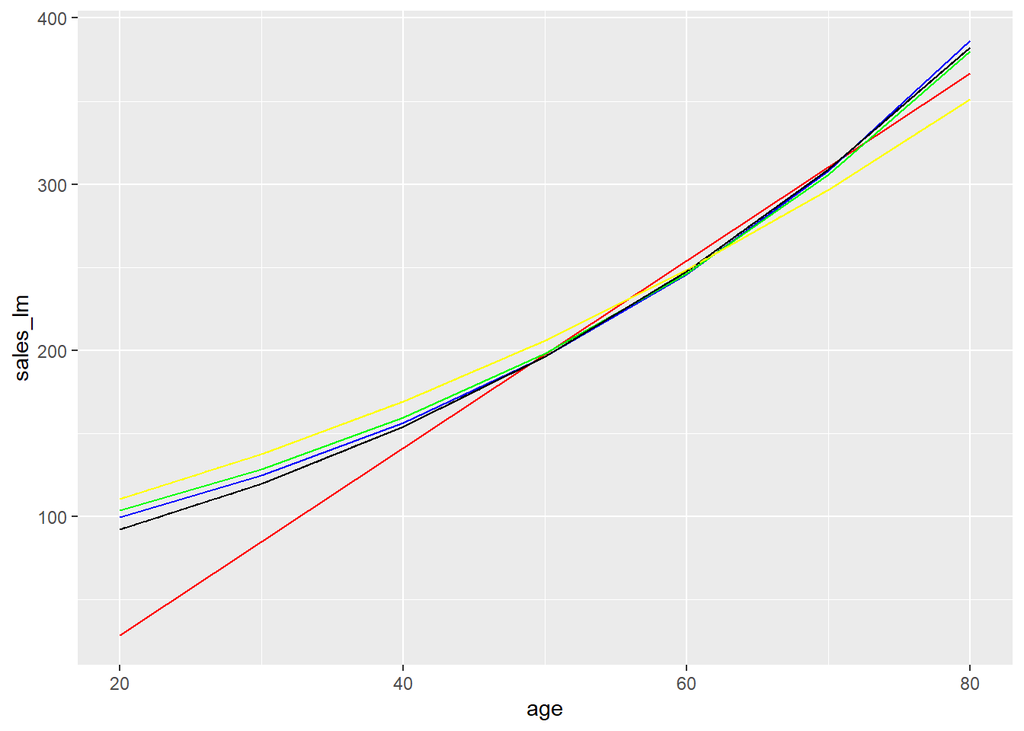

```r
# check age predictions
df_pred$sales_hurd_nb <-
  predict(mod2_hurd_nb,
          newdata = df_pred,
          type = 'response')
# show difference
ggplot(df_pred,aes(x=age)) +
  geom_line(color='red',
            aes(y=sales_lm)) +
  geom_line(color='blue',
            aes(y=sales_poisson)) +
  geom_line(color='green',
            aes(y=sales_tweedie)) +
  geom_line(color='black',
            aes(y=sales_zip)) +
  geom_line(color='yellow',
            aes(y=sales_zinb)) +
  geom_line(color='black',lty=2,
            aes(y=sales_hurd_poisson)) +
  geom_line(color='yellow',lty=2,
            aes(y=sales_hurd_nb))
```

```r
# Check table
df_pred
```

```
##   age  sales_lm sales_poisson sales_tweedie sales_zip sales_zinb sales_hurd_poisson sales_hurd_nb
## 1  20  28.37493      99.62601      103.4877   92.0292   110.6476           92.02751      110.6658
## 2  30  84.75768     124.87628      128.5412  119.6338   137.5243          119.63208      137.5381
## 3  40 141.14044     156.52624      159.6599  153.9634   169.2190          153.96180      169.2275
## 4  50 197.52319     196.19791      198.3122  196.1439   206.1148          196.14278      206.1180
## 5  60 253.90594     245.92439      246.3220  247.3851   248.5463          247.38462      248.5445
## 6  70 310.28869     308.25407      305.9545  308.9904   296.8081          308.99113      296.8023
## 7  80 366.67144     386.38125      380.0235  382.3808   351.1730          382.38321      351.1654
```

- The zero inflated models are very close to the hurdle models! In practice, I often find this to be true. However, the decision to use a Poisson versus a negative binomial distribution has a large impact here.
- I would conclude the negative binomial is correct (or better than the Poisson at least) – it has the flexibility to fit the overdispersion.

# More information

Here are some links to more good resources on these topics:

(http://seananderson.ca/2014/05/18/gamma-hurdle/)

(https://statcompute.wordpress.com/2017/06/29/model-operational-loss-directly-with-tweedie-glm/)

(http://data.library.virginia.edu/getting-started-with-hurdle-models/)

(https://cran.r-project.org/web/packages/pscl/vignettes/countreg.pdf)